# IODS course project

The variables do not seem to quite normally distributed.

```r
library(tidyr); library(dplyr); library(ggplot2)

# plots a glimpse of the variables
glimpse(Boston)
```

```
## Observations: 506
## Variables: 14
## $ crim    <dbl> 0.00632, 0.02731, 0.02729, 0.03237, 0.06905, 0.02985, ...
## $ zn      <dbl> 18.0, 0.0, 0.0, 0.0, 0.0, 0.0, 12.5, 12.5, 12.5, 12.5,...
## $ indus   <dbl> 2.31, 7.07, 7.07, 2.18, 2.18, 2.18, 7.87, 7.87, 7.87, ...
## $ chas    <int> 0, 0, 0, 0, 0, 0, 0, 0, 0, 0, 0, 0, 0, 0, 0, 0, 0, 0, ...
## $ nox     <dbl> 0.538, 0.469, 0.469, 0.458, 0.458, 0.458, 0.524, 0.524...
## $ rm      <dbl> 6.575, 6.421, 7.185, 6.998, 7.147, 6.430, 6.012, 6.172...
## $ age     <dbl> 65.2, 78.9, 61.1, 45.8, 54.2, 58.7, 66.6, 96.1, 100.0,...
## $ dis     <dbl> 4.0900, 4.9671, 4.9671, 6.0622, 6.0622, 6.0622, 5.5605...
## $ rad     <int> 1, 2, 2, 3, 3, 3, 5, 5, 5, 5, 5, 5, 5, 4, 4, 4, 4, 4, ...
## $ tax     <dbl> 296, 242, 242, 222, 222, 222, 311, 311, 311, 311, 311,...
## $ ptratio <dbl> 15.3, 17.8, 17.8, 18.7, 18.7, 18.7, 15.2, 15.2, 15.2, ...
## $ black   <dbl> 396.90, 396.90, 392.83, 394.63, 396.90, 394.12, 395.60...
## $ lstat   <dbl> 4.98, 9.14, 4.03, 2.94, 5.33, 5.21, 12.43, 19.15, 29.9...
## $ medv    <dbl> 24.0, 21.6, 34.7, 33.4, 36.2, 28.7, 22.9, 27.1, 16.5, ...
```

```r
# use gather() to gather columns into key-value pairs and then glimpse() at the resulting data
gather(Boston) %>% glimpse
```

```
## Observations: 7,084
## Variables: 2
## $ key   <chr> "crim", "crim", "crim", "crim", "crim", "crim", "crim", ...
## $ value <dbl> 0.00632, 0.02731, 0.02729, 0.03237, 0.06905, 0.02985, 0....
```

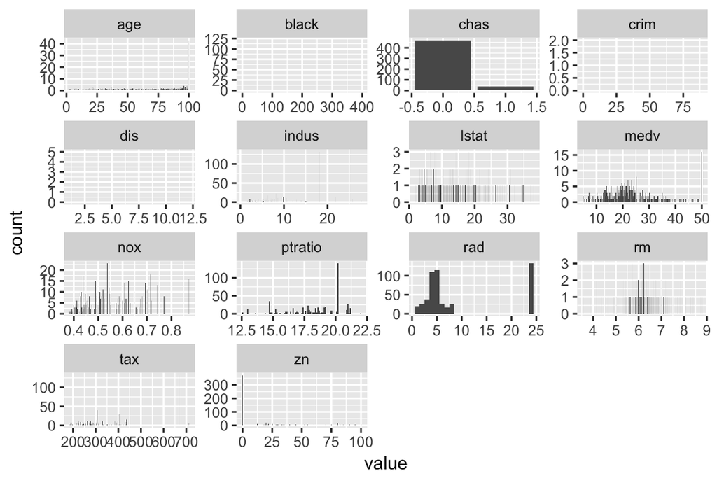

```r
# draw a bar plot of each variable
gather(Boston) %>% ggplot(aes(value)) +geom_bar()+ facet_wrap("key", scales = "free")
```

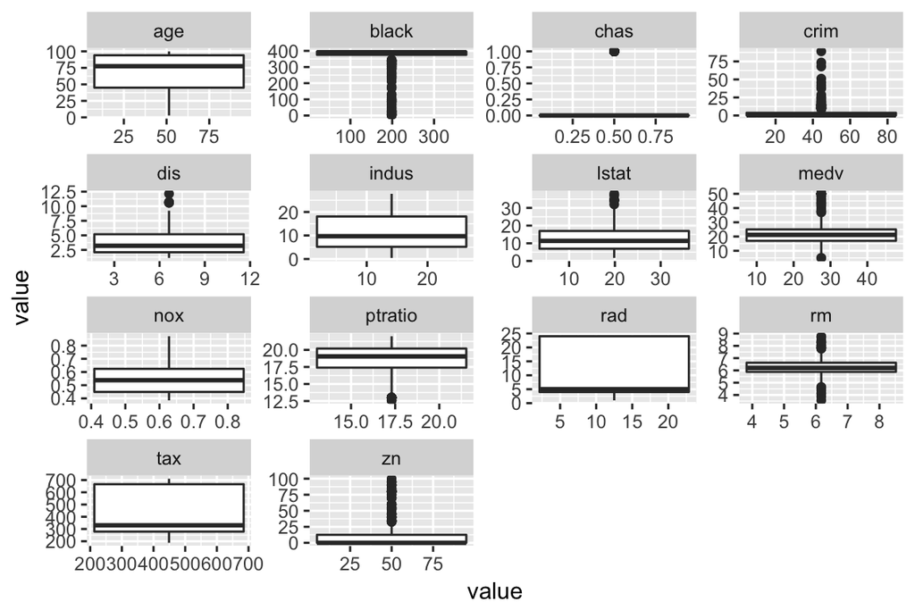

```r
# drawing boxplots of each variable
gather(Boston) %>% ggplot(aes(x = value, y = value)) +geom_boxplot()+ facet_wrap("key", scales = "free")
```

```r
# calculate the correlation matrix and round it
cor_matrix<-cor(Boston) %>% round(digits=2)

# print the correlation matrix
cor_matrix
```

```
##          crim    zn indus  chas   nox    rm   age   dis   rad   tax
## crim     1.00 -0.20  0.41 -0.06  0.42 -0.22  0.35 -0.38  0.63  0.58
## zn      -0.20  1.00 -0.53 -0.04 -0.52  0.31 -0.57  0.66 -0.31 -0.31
## indus    0.41 -0.53  1.00  0.06  0.76 -0.39  0.64 -0.71  0.60  0.72
## chas    -0.06 -0.04  0.06  1.00  0.09  0.09  0.09 -0.10 -0.01 -0.04
## nox      0.42 -0.52  0.76  0.09  1.00 -0.30  0.73 -0.77  0.61  0.67
## rm      -0.22  0.31 -0.39  0.09 -0.30  1.00 -0.24  0.21 -0.21 -0.29
## age      0.35 -0.57  0.64  0.09  0.73 -0.24  1.00 -0.75  0.46  0.51
## dis     -0.38  0.66 -0.71 -0.10 -0.77  0.21 -0.75  1.00 -0.49 -0.53
## rad      0.63 -0.31  0.60 -0.01  0.61 -0.21  0.46 -0.49  1.00  0.91
## tax      0.58 -0.31  0.72 -0.04  0.67 -0.29  0.51 -0.53  0.91  1.00
## ptratio  0.29 -0.39  0.38 -0.12  0.19 -0.36  0.26 -0.23  0.46  0.46
## black   -0.39  0.18 -0.36  0.05 -0.38  0.13 -0.27  0.29 -0.44 -0.44
## lstat    0.46 -0.41  0.60 -0.05  0.59 -0.61  0.60 -0.50  0.49  0.54
## medv    -0.39  0.36 -0.48  0.18 -0.43  0.70 -0.38  0.25 -0.38 -0.47
##         ptratio black lstat  medv
## crim       0.29 -0.39  0.46 -0.39
## zn        -0.39  0.18 -0.41  0.36
## indus      0.38 -0.36  0.60 -0.48
## chas      -0.12  0.05 -0.05  0.18
## nox        0.19 -0.38  0.59 -0.43
## rm        -0.36  0.13 -0.61  0.70
## age        0.26 -0.27  0.60 -0.38
## dis       -0.23  0.29 -0.50  0.25
## rad        0.46 -0.44  0.49 -0.38
## tax        0.46 -0.44  0.54 -0.47
## ptratio    1.00 -0.18  0.37 -0.51
## black     -0.18  1.00 -0.37  0.33
## lstat      0.37 -0.37  1.00 -0.74
## medv      -0.51  0.33 -0.74  1.00
```

## part 4

Below code standardises the data and prints out the summaries of the data. Then categorical variables are created of the crime rate in Boston dataset. Then the set is further divided into train and test set so that 80% of the set is in the training set.

All the data is now divided around zero and there is the new variable crime with the classes: “low”,“med_low”, “med_high”, “high”.

```r
# standardise the variables
boston_scaled <- scale(Boston)

# print out the summaries of the sacaled variables
summary(boston_scaled)
```

```
##       crim                 zn               indus
##  Min.   :-0.419367   Min.   :-0.48724   Min.   :-1.5563
##  1st Qu.:-0.410563   1st Qu.:-0.48724   1st Qu.:-0.8668
##  Median :-0.390280   Median :-0.48724   Median :-0.2109
##  Mean   : 0.000000   Mean   : 0.00000   Mean   : 0.0000
##  3rd Qu.: 0.007389   3rd Qu.: 0.04872   3rd Qu.: 1.0150
##  Max.   : 9.924110   Max.   : 3.80047   Max.   : 2.4202
##       chas              nox                rm               age
##  Min.   :-0.2723   Min.   :-1.4644   Min.   :-3.8764   Min.   :-2.3331
##  1st Qu.:-0.2723   1st Qu.:-0.9121   1st Qu.:-0.5681   1st Qu.:-0.8366
##  Median :-0.2723   Median :-0.1441   Median :-0.1084   Median : 0.3171
##  Mean   : 0.0000   Mean   : 0.0000   Mean   : 0.0000   Mean   : 0.0000
##  3rd Qu.:-0.2723   3rd Qu.: 0.5981   3rd Qu.: 0.4823   3rd Qu.: 0.9059
##  Max.   : 3.6648   Max.   : 2.7296   Max.   : 3.5515   Max.   : 1.1164
##       dis               rad               tax             ptratio
##  Min.   :-1.2658   Min.   :-0.9819   Min.   :-1.3127   Min.   :-2.7047
##  1st Qu.:-0.8049   1st Qu.:-0.6373   1st Qu.:-0.7668   1st Qu.:-0.4876
##  Median :-0.2790   Median :-0.5225   Median :-0.4642   Median : 0.2746
##  Mean   : 0.0000   Mean   : 0.0000   Mean   : 0.0000   Mean   : 0.0000
##  3rd Qu.: 0.6617   3rd Qu.: 1.6596   3rd Qu.: 1.5294   3rd Qu.: 0.8058
##  Max.   : 3.9566   Max.   : 1.6596   Max.   : 1.7964   Max.   : 1.6372
##      black             lstat              medv
##  Min.   :-3.9033   Min.   :-1.5296   Min.   :-1.9063
##  1st Qu.: 0.2049   1st Qu.:-0.7986   1st Qu.:-0.5989
##  Median : 0.3808   Median :-0.1811   Median :-0.1449
##  Mean   : 0.0000   Mean   : 0.0000   Mean   : 0.0000
##  3rd Qu.: 0.4332   3rd Qu.: 0.6024   3rd Qu.: 0.2683
##  Max.   : 0.4406   Max.   : 3.5453   Max.   : 2.9865
```

```r
#cheching the classes of the boston_scaled object
class(boston_scaled)
```

```
## [1] "matrix"
```

```r
#creating a dataframe out of the boston_scaled object
boston_scaled <- as.data.frame(boston_scaled)
#checking that the transformation worked
is.data.frame(boston_scaled)
```

```
## [1] TRUE
```

```r
#saving the scaled crime rate as scaled_crim
scaled_crim <- boston_scaled$crim

#printing out the summary of scaled crime rate
summary(scaled_crim)
```

```
##      Min.   1st Qu.    Median      Mean   3rd Qu.      Max.
## -0.419400 -0.410600 -0.390300  0.000000  0.007389  9.924000
```

```r
#creating ad quantile vector of crime and then

# create a quantile vector of crim and print it
bins <- quantile(scaled_crim)

#creating a categorical variable "crime"
crime <- cut(scaled_crim, breaks = bins, include.lowest = TRUE, labels = c("low","med_low", "med_high", "high"))

# taking a look at the new factor crime
table(crime)
```

```
## crime
##      low  med_low med_high     high
##      127      126      126      127
```

```r
bins
```

```
##           0%          25%          50%          75%         100%
## -0.419366929 -0.410563278 -0.390280295  0.007389247  9.924109610
```

```r
#removing the original crim from the dataset
boston_scaled <- dplyr::select(boston_scaled, -crim)

#adding the new categorical value to the data
boston_scaled <- data.frame(boston_scaled, crime)


#checking the number of rows in the dataset
n <- nrow(Boston)
#choosing randomly 80% of the rows
ind <- sample(n, size = n * 0.8)

# creating a training set
train <- boston_scaled[ind,]

#creating the testing set
test <- boston_scaled[-ind,]
```

All the data is now divided around zero and there is the new variable crime with the classes: “low”,“med_low”, “med_high”, “high”.